# Course Project 1

Joshua Huber

July 29, 2017

## Loading and preprocessing the data

First things first, let’s load the data set from the CSV file:

```r
rawdata <- read.csv("activity.csv", stringsAsFactors = FALSE)
```

Cleanup data by

- converting the string dates to proper (POSIXct) dates
- removing any records with NA steps

```r
data1 <- rawdata[complete.cases(rawdata),]
data1$date <- as.POSIXct(data1$date)
```

## Steps, by day

```r
data1_by_day <- aggregate(steps ~ date, data1, sum)
summary(data1_by_day$steps)
```

```
##    Min. 1st Qu.  Median    Mean 3rd Qu.    Max.
##      41    8841   10765   10766   13294   21194
```

A histogram of the data, showing distribution of steps over days.

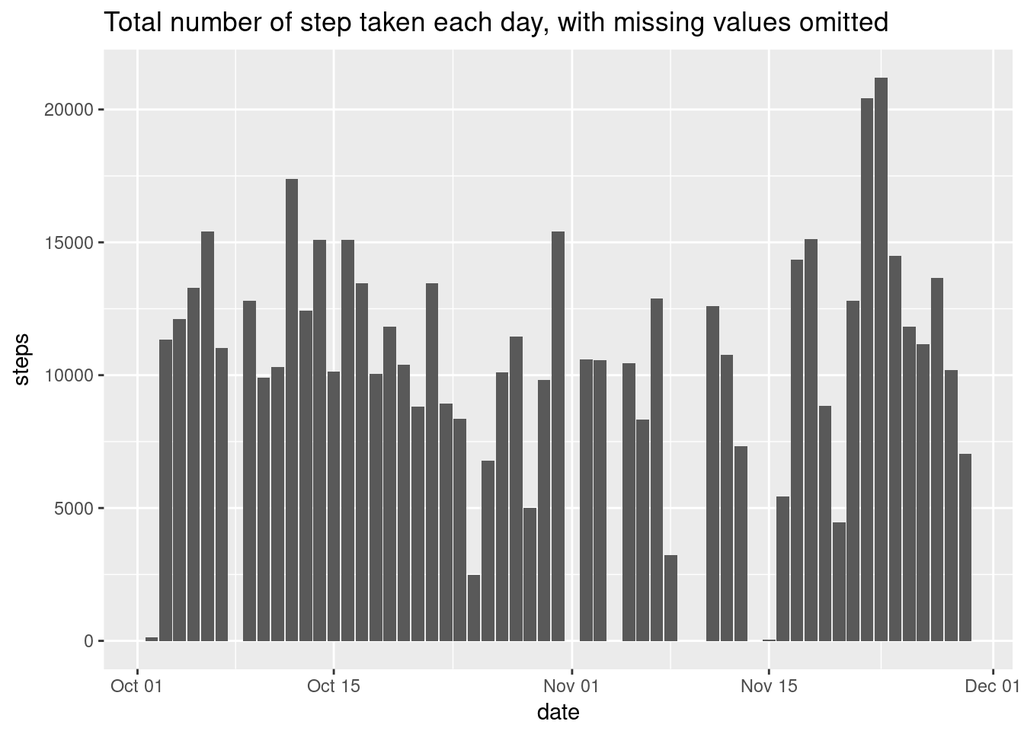

```r
library(ggplot2)
ggplot(aes(x=date, y=steps), data = data1_by_day)+
  geom_bar(stat = 'identity') +
  ggtitle("Total number of step taken each day, with missing values omitted")
```

## Daily activity pattern

Aggregate the data, grouping by interval. The maximum occurs in the 8:35am interval, with an average of approximately 206 steps during this interval.

```r
data1_by_interval <- aggregate(steps ~ interval, data1, mean)
data1_by_interval[which.max(data1_by_interval$steps),]
```

```
##     interval    steps
## 104      835 206.1698
```

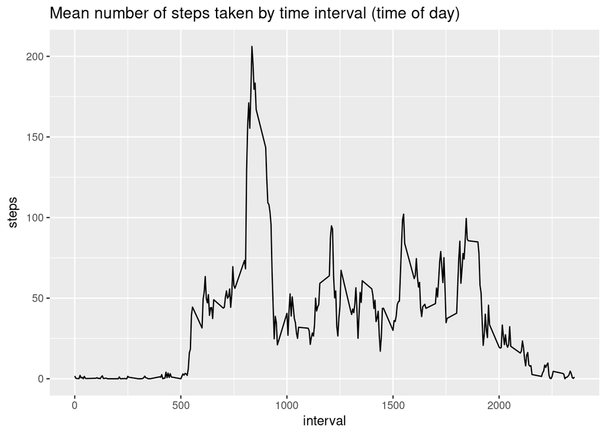

```r
library(ggplot2)
ggplot(aes(x=interval, y=steps), data = data1_by_interval) +
  geom_line(stat = 'identity') +
  ggtitle("Mean number of steps taken by time interval (time of day)")
```

## Imputing missing values

We start from the raw data with the incomplete cases (those with NA values for at least one variable) included. Of the 17568 observations, 2304 of them have variables with NA values.

```r
data2 <- rawdata
data2$date <- as.POSIXct(rawdata$date)
sum(!complete.cases(data2))
```

```
## [1] 2304
```

We will do a simple fill on the NA values by setting the steps to the average for that interval (5 minute slice of a day) across all days. To accomplish this, we are using the plyr package and code snippet suggested by Hadley Wickham in a mailing list post at https://stat.ethz.ch/pipermail/r-help/2009-June/393742.html.We then verify all cases are complete, i.e.: we expect zero incomplete cases after the imputation.

```r
library(plyr)
impute.mean <- function(x) replace(x, is.na(x), mean(x, na.rm = TRUE))
data2 <- ddply(data2, ~ interval, transform, steps = impute.mean(steps))
sum(!complete.cases(data2))
```

```
## [1] 0
```

Make a histogram of the total number of steps taken each day and Calculate and report the mean and median total number of steps taken per day. Do these values differ from the estimates from the first part of the assignment? What is the impact of imputing missing data on the estimates of the total daily number of steps?

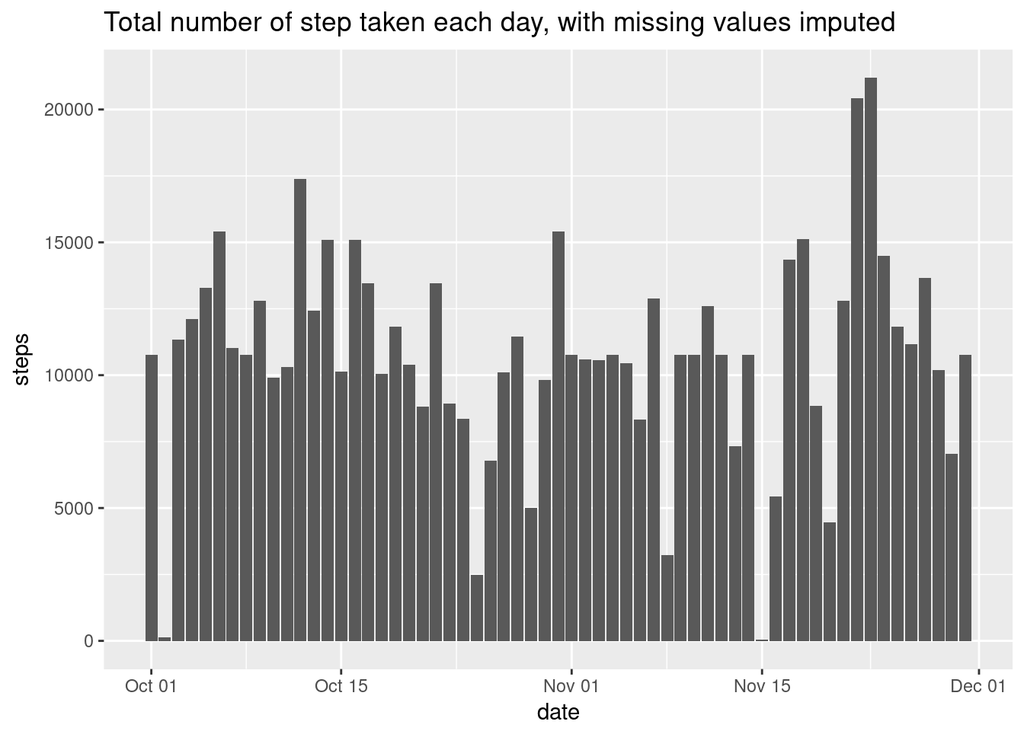

```r
data2_by_day <- aggregate(steps ~ date, data2, sum)
library(ggplot2)
ggplot(aes(x=date, y=steps), data = data2_by_day) +
  geom_bar(stat = 'identity') +
  ggtitle("Total number of step taken each day, with missing values imputed")
```

Below is the summary statistics of the data set with missing values imputed.

```r
summary(data2_by_day$steps)
```

```
##    Min. 1st Qu.  Median    Mean 3rd Qu.    Max.
##      41    9819   10766   10766   12811   21194
```

Compare the total number of steps in the data sets with missing values omitted vs. imputed.

```r
sum(data1$steps); sum(data2$steps)
```

```
## [1] 570608
```

```
## [1] 656737.5
```

Let’s also collect the standard deviation, just to see if imputing missing values changes the dispersion of the data

```r
sd(data1$steps); sd(data2$steps)
```

```
## [1] 111.9955
```

```
## [1] 105.3248
```

**Conclusion:** We summarize the two data sets below. It does not appear that imputing missing values significantly affected the median or mean values, however it did decreate the standard deviation and increase the total values.

[output not shown]

## Weekday vs. weekend activity

Create a new factor variable in the dataset with two levels – “weekday” and “weekend” indicating whether a given date is a weekday or weekend day.

```r
data1$weekday<-as.factor(weekdays(data1$date) %in% c("Saturday","Sunday"))
levels(data1$weekday)<-c("weekday","weekend")
```

Make a panel plot containing a time series plot (i.e. type = “l”) of the 5-minute interval (x-axis) and the average number of steps taken, averaged across all weekday days or weekend days (y-axis).

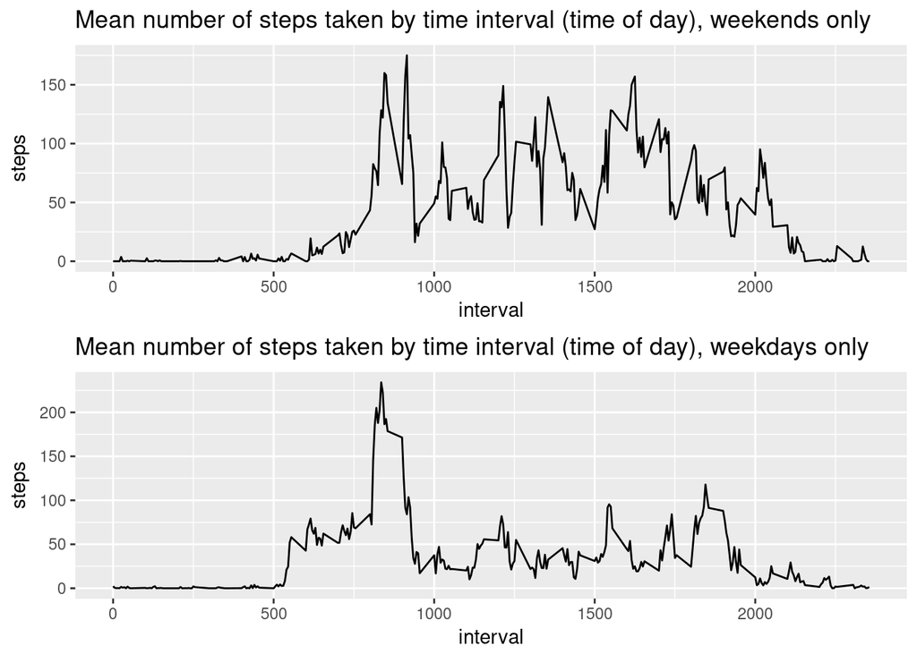

```r
weekend_data1_by_interval <- aggregate(steps ~ interval,
                                       data1[data1$weekday=="weekend",], mean)
weekday_data1_by_interval <- aggregate(steps ~ interval,
                                       data1[data1$weekday=="weekday",], mean)
library(ggplot2)
library(grid)
plot1 <- ggplot(aes(x=interval, y=steps), data = weekend_data1_by_interval) +
         geom_line(stat = 'identity') +
         ggtitle("Mean number of steps taken by time interval (time of day), weekends only")

plot2 <- ggplot(aes(x=interval, y=steps), data = weekday_data1_by_interval) +
         geom_line(stat = 'identity') +
         ggtitle("Mean number of steps taken by time interval (time of day), weekdays only")

grid.newpage()
grid.draw(rbind(ggplotGrob(plot1), ggplotGrob(plot2), size = "last"))
```